# Coverage Probability

Ty Painter

December 02, 2020

# 1 Introduction

In this blog I will examine the 95% confidence interval for sample medians through simulation. I will then elaborate on what coverage probability is and how it applies to this simulation.

## 1.1 Background

Coverage probability is essential to estimating confidence intervals. For this specific simulation, the 95% confidence interval will be defined as the middle 95% of the sampling distribution. The coverage probability will be defined as the overall intervals that contain the specified population parameter, in this case the median. Theoretically, the 95% confidence interval will contain the population mean 95% of the time.

# 2 Methods

## 2.1 Generate a single sample from a standard normal distribution of size N = 201.

```r
set.seed(11222020)
N = 201
samp <- rnorm(N)
# parameter of interest is median
median(samp) # sample median, not true median
```

```
## [1] 0.08858358
```

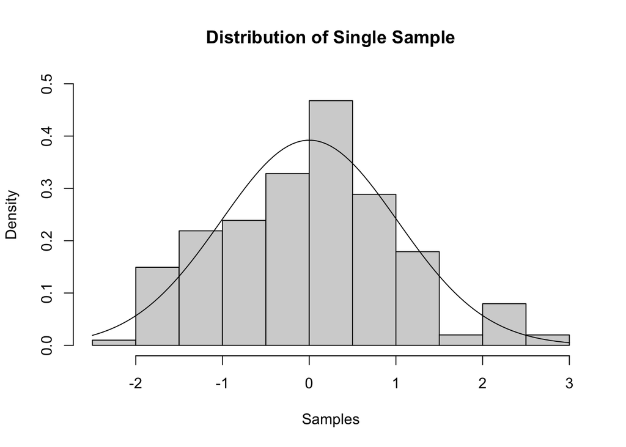

```r
mle.mean <- mean(samp)
mle.sd <- sqrt(((N-1)/N)*var(samp))

hist(samp, freq=FALSE,
     breaks = 15,
     ylim=c(0,.5),
     main = "Distribution of Single Sample",
     xlab = "Samples")
curve(dnorm(x, mle.mean, mle.sd), add = TRUE)
```

I generated sample of 201 numbers from random normal distribution. By doing this, I would expect the median to be around 0 and it was very close at 0.08. I used MLE to estimate the distribution by obtaining the mean and standard deviation from the random sample. Although the MLE mean and standard deviation are not the “true” mean and standard deviation, the MLE calculations are good estimators of what the “true” mean and standard deviation will be.

## 2.2 Approximate the sampling distribution of the median, conditional on the estimate of the distribution in the previous step.

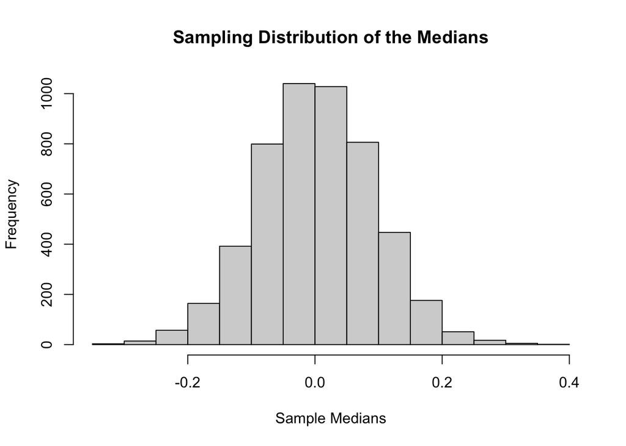

```r
n = 5000 # 5,000 replicates
meds = NA

for (i in 1:n){
  re.samp = rnorm(N, mle.mean, mle.sd) # resample 201 numbers, with sample mean and sd
  meds[i] = median(re.samp) # record the median of each replicate sample
}

hist(meds, # display distribution of all the replicate sample medians
     main = "Sampling Distribution of the Medians",
     #ylim=c(0,.5),
     xlab = "Sample Medians")
```

```r
# hist(rbeta(5000, 101, 101) %>% # random beta distribution of 5,000 observations of medians (101 of 201)
#        qnorm(mean = mle.mean, sd = mle.sd)) # passed into a normal distribution
```

When resampling the data and finding the medians of 5,000 replicates, the medians should become more condensed around 0 compare to the original sample.

## 2.3 Describe how you calculate a 95% confidence interval from the approximated sampling distribution.

```r
ci <- quantile(meds, c(0.025, 0.975))
ci
```

```
##       2.5%      97.5%
## -0.1762583  0.1797620
```

```r
(ci[1] < 0 & ci[2] > 0)
```

```
## 2.5%
## TRUE
```

I used the quantile function calculate the 95% confidence interval of the sample medians. The lower limit is -0.18 and the upper limit is 0.18 and 0 falls within these limits.

## 2.4 Explain the concept of coverage probability. Explain your code for calculating the coverage probability.

```r
gen.ci.med = function(n = 5000, N=201, param.int = 0){ # function to generate confidence interval medians

  samp <- rnorm(N) # random normal distribution of number

  mle.mean <- mean(samp)
  mle.sd <- sqrt(((N-1)/N)*var(samp))
  meds = NA

  for (i in 1:n){ # generates vector of 5,000 medians
    re.samp = rnorm(N, mle.mean, mle.sd) # resample 201 numbers, with sample mean and sd
    meds[i] = median(re.samp) # record the median of each replicate sample
  }

  ci <- quantile(meds, c(0.025, 0.975)) # calculate 95% confidence interval
  return (ci[1] < param.int & ci[2] > param.int) # test if parameter is within the 95% confidence interval
}
```

To calculate the coverage probability I created random normal distribution of 201 numbers. I then calculated the sample mean and standard deviation. I then ran 5,000 replicates and found the median of each replicate. I then used the quantile function to establish the 95% confidence interval and ran a test to determine if the input parameter is within that interval.

## 2.5 Perform the simulation and report the results.

```r
ci.contain = NA
for (i in 1:1000){ # run 1,000 simulations
  ci.contain[i] = gen.ci.med() # vector of T/F
}

mean(ci.contain) # probability of T = probability of parameter being within the CI
```

```
## [1] 0.985
```

To perform the simulation ran the coverage probability function 1,000 times. This produced a vector of 1,000 True/False variables. Calculating the mean of this vector finds the overall probability of the median being within the 95% confidence interval. The result was 98.5% which is slightly higher than the generalized 95% confidence interval.

# 3 Conclusions

The main takeaway from this blog is that the 95% confidence interval gives a better understanding of where the highest density distribution lies. Also as the sample size, replicates, and the simulations in crease, the coverage probability approaches 0.95.